# Case Study: How Does a Bike-Share Navigate Speedy Success?

Said Boutejdir.

20/12/2021

```r
library(tidyverse)
library(lubridate)
```

```r
library(ggplot2)
```

## 1. Identifying the business task.

Delve into bike-share data and discover **how do annual members and casual riders use Cyclistic bikes differently**, which will help Stakeholders design marketing strategies based on digital media to convert casual riders **if they are resulting less profitable** than members riders.

## 2. Describing the used data sources.

Cyclistic’s historical trip data source used in this analysis project is a **public data** containing the previous 12 months of Cyclistic trip data (starting from December 2020 up to November 2021) made available by Motivate International Inc. under this [license](https://www.divvybikes.com/data-license-agreement). The data is openly reachable by the current [link](https://divvy-tripdata.s3.amazonaws.com/index.html). The data source is presented in 12 csv files, every single file is containing all trip activities for a given month, covering values of 13 attributes listed below over the whole month.

### Taking the first look on the data.

As a starting step, we will just analyse the first file (202012) and try to extract and plot the most important values from it.

```r
Bike_trips_df <- read.csv("data/zip/202012-divvy-tripdata.csv")
glimpse(Bike_trips_df)
```

```
## Rows: 131,573
## Columns: 13
## $ ride_id            <chr> "70B6A9A437D4C30D", "158A465D4E74C54A", "5262016E0F~
## $ rideable_type      <chr> "classic_bike", "electric_bike", "electric_bike", "~
## $ started_at         <chr> "2020-12-27 12:44:29", "2020-12-18 17:37:15", "2020~
## $ ended_at           <chr> "2020-12-27 12:55:06", "2020-12-18 17:44:19", "2020~
## $ start_station_name <chr> "Aberdeen St & Jackson Blvd", "", "", "", "", "", "~
## $ start_station_id   <chr> "13157", "", "", "", "", "", "", "", "", "", "", ""~
## $ end_station_name   <chr> "Desplaines St & Kinzie St", "", "", "", "", "", ""~
## $ end_station_id     <chr> "TA1306000003", "", "", "", "", "", "", "", "", "",~
## $ start_lat          <dbl> 41.87773, 41.93000, 41.91000, 41.92000, 41.80000, 4~
## $ start_lng          <dbl> -87.65479, -87.70000, -87.69000, -87.70000, -87.590~
## $ end_lat            <dbl> 41.88872, 41.91000, 41.93000, 41.91000, 41.80000, 4~
## $ end_lng            <dbl> -87.64445, -87.70000, -87.70000, -87.70000, -87.590~
## $ member_casual      <chr> "member", "member", "member", "member", "member", "~
```

### Getting some valuable evidence from the data and inspecting for bias and trustworthiness.

By now, we are familiar with this data set, and we know that it contains 13 attributes or column names that we can inspect deeper, first we will try to check for the data integrity and credibility, and then we will try to filter out any ineffective values.

```r
Bike_trips_df_v2 = na.omit(Bike_trips_df)
# distinct(Bike_trips_df_v2)
# glimpse(Bike_trips_df_v2)
Bike_trips_df_v2  %>%
  summarize(min_rider_id = min(nchar(ride_id)),
            max_rider_id = max(nchar(ride_id)),
            min_start_lat = min(start_lat),
            max_start_lat = max(start_lat),
            max_end_lat = max(end_lat),
            min_end_lat = min(end_lat),
            min_start_lng = min(start_lng),
            max_start_lng = max(start_lng),
            max_end_lng = max(end_lng),
            min_end_lng = min(end_lng) )
```

```
##   min_rider_id max_rider_id min_start_lat max_start_lat max_end_lat min_end_lat
## 1           16           16         41.65         42.07       42.07       41.65
##   min_start_lng max_start_lng max_end_lng min_end_lng
## 1        -87.78     -87.52823   -87.52823      -87.79
```

After inspecting the values and searching for outliers and bias, we must check the credibility of data and remove all rows in which the round trip duration is less than 1 minute (60 seconds) or containing wrong data like the starting time (started_at) later than ending trip time (ended_at) which is not possible!!.

```r
Bike_trips_df_v3 <- Bike_trips_df %>%
        filter(as.duration( ymd_hms(ended_at)-ymd_hms(started_at)) >= 60 ) %>%
        mutate(trip_duration = as.duration(ymd_hms(ended_at)-ymd_hms(started_at)))

Bike_trips_df_v3  %>%
  group_by(rideable_type, member_casual) %>%
  summarize(sum_trip_seconds = sum(trip_duration) ,
            average_trip_time = mean(trip_duration) / 60,
            number_rows = n_distinct(ride_id) ,
            .groups = 'drop') %>%
  arrange(rideable_type, desc(member_casual))
```

```
## # A tibble: 6 x 5
##   rideable_type member_casual sum_trip_seconds average_trip_time number_rows
##   <chr>         <chr>                    <dbl>             <dbl>       <int>
## 1 classic_bike  member                47038496              13.4       58649
## 2 classic_bike  casual                17855968              26.5       11218
## 3 docked_bike   member                 5912031              12.8        7697
## 4 docked_bike   casual                17085339              58.0        4912
## 5 electric_bike member                24389337              12.1       33486
## 6 electric_bike casual                13375687              16.5       13535
```

### Visualising some keys values of our data

With our findings, we can try to plot some graph in other to get a big picture of our current data source.

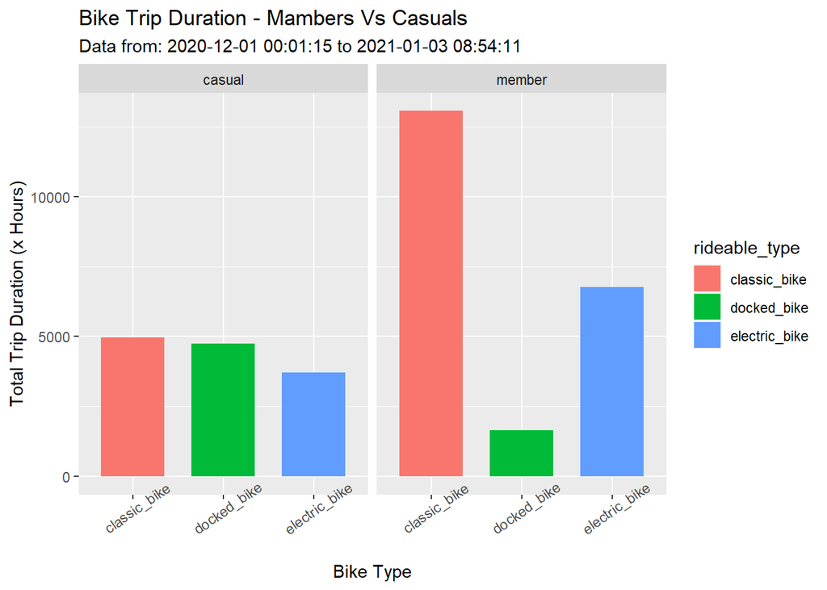

```r
mindate <- min(Bike_trips_df$started_at)
maxdate <- max(Bike_trips_df$ended_at)
Bike_trips_df_Plot <- Bike_trips_df_v3  %>%
  group_by(rideable_type, member_casual) %>%
  summarize(sum_trip_seconds = sum(trip_duration) / 3600,
            average_trip_time = mean(trip_duration) / 60,
            number_rows = n_distinct(ride_id) ,
            .groups = 'drop') %>%
  arrange(rideable_type, desc(member_casual))

ggplot(Bike_trips_df_Plot) +
    geom_bar(mapping= aes(x=rideable_type, y=sum_trip_seconds, fill=rideable_type), stat='identity', width=0.7) +
    facet_wrap(~member_casual) +
    theme(axis.text.x = element_text(angle = 35)) +
    labs(title="Bike Trip Duration - Mambers Vs Casuals",
        subtitle=paste0("Data from: ", mindate, " to ", maxdate) ,
        x="Bike Type",
        y="Total Trip Duration (x Hours)")
```

Ploting the total trip duration in hours for members and casuals.

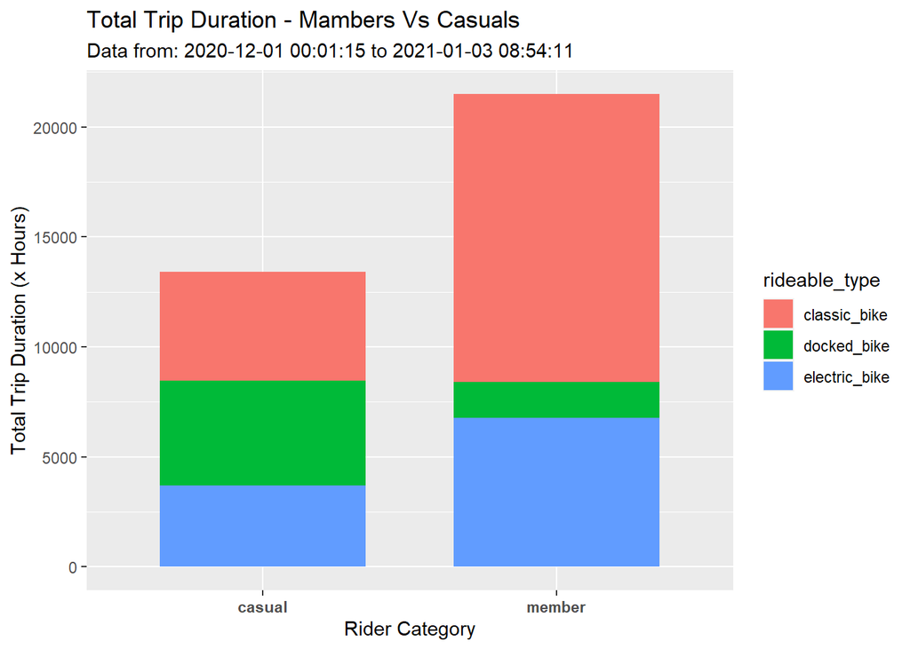

```r
ggplot(Bike_trips_df_v3) +
    geom_bar(mapping= aes(x = member_casual, y=trip_duration/3600, fill=rideable_type), stat = 'identity', width = 0.7) +
    theme(axis.text.x = element_text(face="bold")) +
    labs(title="Total Trip Duration - Mambers Vs Casuals",
        subtitle=paste0("Data from: ", mindate, " to ", maxdate) ,
        x="Rider Category",
        y="Total Trip Duration (x Hours)")
```

Ploting the trip duration average in minutes for members and casuals.

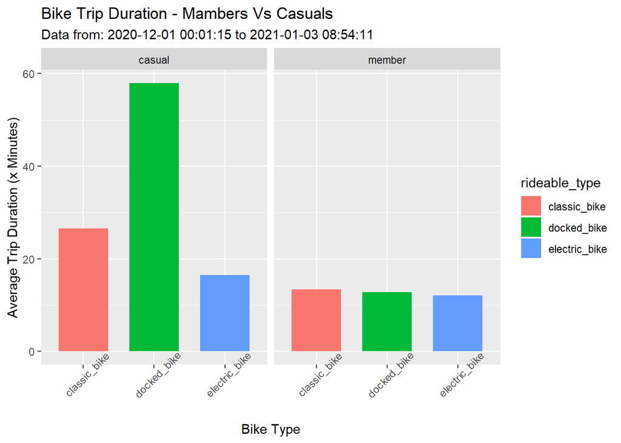

```r
ggplot(Bike_trips_df_Plot) +
    geom_bar(mapping= aes(x=rideable_type,  y=average_trip_time, fill=rideable_type), stat='identity', width=0.7) +
    facet_wrap(~member_casual) +
    theme(axis.text.x = element_text(angle = 45)) +
    labs(title="Bike Trip Duration - Mambers Vs Casuals",
        subtitle=paste0("Data from: ", mindate, " to ", maxdate) ,
        x="Bike Type",
        y="Average Trip Duration (x Minutes)")
```

### Summarizing the whole data source. (merging the 12 files)

After having a look at every csv file and examining its content, we by now, will try to analyse the whole data source extracting and plotting the most important values from it.

```r
files <- list.files(path = "./Data/Zip/", pattern = "*.csv")
df <- files %>%
  map(function(x) {
    read.csv(paste0("./Data/Zip/", x))
  }) %>%
  reduce(rbind)

glimpse(df)
```

```
## Rows: 5,479,096
## Columns: 13
## $ ride_id            <chr> "70B6A9A437D4C30D", "158A465D4E74C54A", "5262016E0F~
## $ rideable_type      <chr> "classic_bike", "electric_bike", "electric_bike", "~
## $ started_at         <chr> "2020-12-27 12:44:29", "2020-12-18 17:37:15", "2020~
## $ ended_at           <chr> "2020-12-27 12:55:06", "2020-12-18 17:44:19", "2020~
## $ start_station_name <chr> "Aberdeen St & Jackson Blvd", "", "", "", "", "", "~
## $ start_station_id   <chr> "13157", "", "", "", "", "", "", "", "", "", "", ""~
## $ end_station_name   <chr> "Desplaines St & Kinzie St", "", "", "", "", "", ""~
## $ end_station_id     <chr> "TA1306000003", "", "", "", "", "", "", "", "", "",~
## $ start_lat          <dbl> 41.87773, 41.93000, 41.91000, 41.92000, 41.80000, 4~
## $ start_lng          <dbl> -87.65479, -87.70000, -87.69000, -87.70000, -87.590~
## $ end_lat            <dbl> 41.88872, 41.91000, 41.93000, 41.91000, 41.80000, 4~
## $ end_lng            <dbl> -87.64445, -87.70000, -87.70000, -87.70000, -87.590~
## $ member_casual      <chr> "member", "member", "member", "member", "member", "~
```

### Getting some valuable evidence from the data and inspecting for bias and trustworthiness.

By now, we are familiar with this data set, and we know that it contains 13 attributes or column names that we can inspect deeper, first we will try to check for the data integrity and credibility, and then we will try to filter out any ineffective values.

```r
df_v2 = na.omit(df)
df_v2  %>%
  summarize(min_rider_id = min(nchar(ride_id)),
            max_rider_id = max(nchar(ride_id)),
            min_start_lat = min(start_lat),
            max_start_lat = max(start_lat),
            max_end_lat = max(end_lat),
            min_end_lat = min(end_lat),
            min_start_lng = min(start_lng),
            max_start_lng = max(start_lng),
            max_end_lng = max(end_lng),
            min_end_lng = min(end_lng) )
```

```
##   min_rider_id max_rider_id min_start_lat max_start_lat max_end_lat min_end_lat
## 1           16           16         41.64         42.07    42.16812       41.39
##   min_start_lng max_start_lng max_end_lng min_end_lng
## 1        -87.84        -87.52      -87.49      -88.97
```

After inspecting the values and searching for outliers and bias, we must check the credibility of the whole data and remove all rows in which the round trip duration is less than 1 minute (60 seconds) or containing wrong data like the starting time (started_at) later than ending trip time (ended_at) which is not possible!!.

```r
df_v3 <- df %>%
        filter(as.duration( ymd_hms(ended_at)-ymd_hms(started_at)) >= 60 ) %>%
        mutate(trip_duration = as.duration(ymd_hms(ended_at)-ymd_hms(started_at)))

df_v3  %>%
  group_by(rideable_type, member_casual) %>%
  summarize(sum_trip_seconds = sum(trip_duration) ,
            average_trip_time = mean(trip_duration) / 60,
            number_rows = n_distinct(ride_id) ,
            .groups = 'drop') %>%
  arrange(rideable_type, desc(member_casual))
```

```
## # A tibble: 6 x 5
##   rideable_type member_casual sum_trip_seconds average_trip_time number_rows
##   <chr>         <chr>                    <dbl>             <dbl>       <int>
## 1 classic_bike  member              1672946367              14.4     1934549
## 2 classic_bike  casual              2182659260              29.2     1244956
## 3 docked_bike   member                 5912189              12.8        7698
## 4 docked_bike   casual              1517006887              81.5      310410
## 5 electric_bike member               787937791              13.2      997645
## 6 electric_bike casual              1105444543              20.5      900439
```

Ploting the total trip duration in hours for members and casuals.

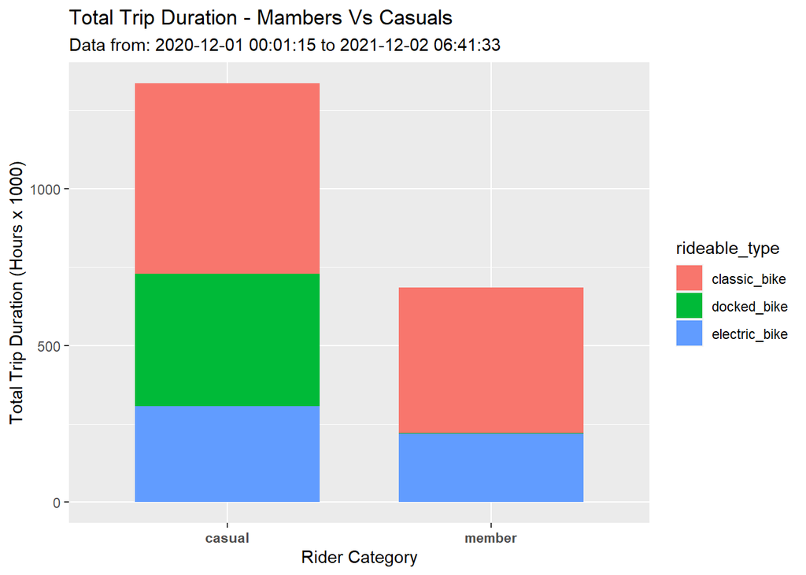

```r
mindate <- min(df$started_at)
maxdate <- max(df$ended_at)
ggplot(df_v3) +
    geom_bar(mapping= aes(x = member_casual, y=trip_duration/3600000, fill=rideable_type), stat = 'identity', width = 0.7) +
    theme(axis.text.x = element_text(face="bold")) +
    labs(title="Total Trip Duration - Mambers Vs Casuals",
        subtitle=paste0("Data from: ", mindate, " to ", maxdate) ,
        x="Rider Category",
        y="Total Trip Duration (Hours x 1000)")
```

### Visualising some keys values of our data

With our findings, we can try to plot some graph in other to get a big picture of our current data source.

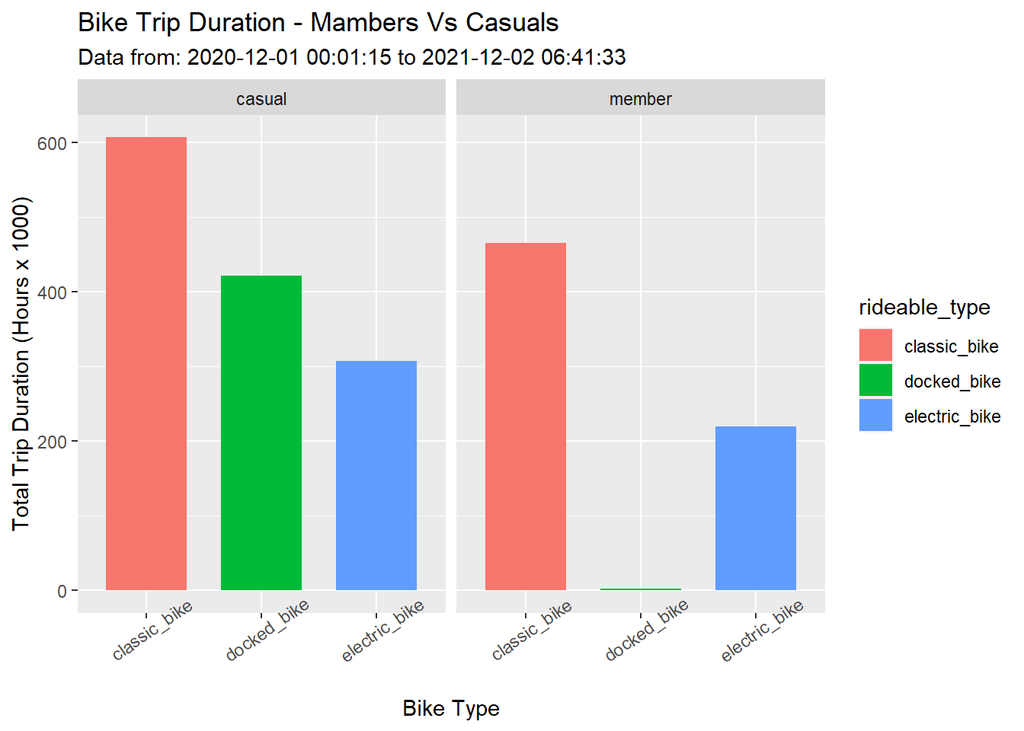

```r
df_Plot <- df_v3  %>%
  group_by(rideable_type, member_casual) %>%
  summarize(sum_trip_seconds = sum(trip_duration) / 3600000,
            average_trip_time = mean(trip_duration) / 60,
            number_rows = n_distinct(ride_id) ,
            .groups = 'drop') %>%
  arrange(rideable_type, desc(member_casual))

ggplot(df_Plot) +
    geom_bar(mapping= aes(x=rideable_type, y=sum_trip_seconds, fill=rideable_type), stat='identity', width=0.7) +
    facet_wrap(~member_casual) +
    theme(axis.text.x = element_text(angle = 35)) +
    labs(title="Bike Trip Duration - Mambers Vs Casuals",
        subtitle=paste0("Data from: ", mindate, " to ", maxdate) ,
        x="Bike Type",
        y="Total Trip Duration (Hours x 1000)")
```